# DATASCI 151 - Introduction to Statistical Computing II

Jupyter Notebooks, Packages, Variables, and Lists

Danilo Freire

danilo.freire@emory.edu

Department of Data and Decision Sciences  
Emory University

# Nice to see you all again! 😊

## Today’s agenda

### Installing packages and working with variables and lists

- Python is a versatile programming language, but it doesn’t come with all the tools we need
- Packages are collections of functions that extend Python’s capabilities
- There are thousands of packages available, and we can install them using conda install or pip install
- We will also learn about variables and lists
- Variables are containers that store data values
- Lists are collections of items that can be of different types
- Today, we will learn how to create, access, and modify variables and lists

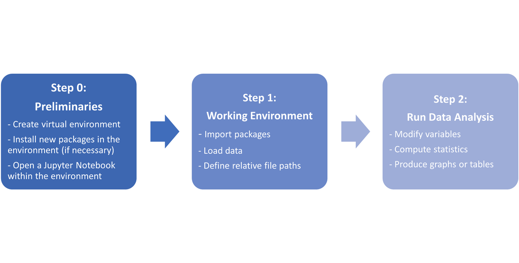

# Python environments

## What is a Python environment?

- A [Python environment](https://docs.conda.io/projects/conda/en/latest/user-guide/tasks/manage-environments.html) is a self-contained folder with its own Python and packages
- It helps you avoid conflicts between projects
- You can have many environments, each with different versions
- Environments are isolated, so changes in one do not affect the others
- You can create, activate, and deactivate them from the command line or Anaconda Navigator
- The default one is called `base` and ships with Anaconda

[figure not shown]

## Opening the terminal in VS Code

- All `conda` commands run inside VS Code’s integrated terminal
- Open it from the menu: **View → Terminal** (or press `` Ctrl + ` ``)

### macOS

- The terminal opens with zsh by default
- The first time only, run:

```
conda init zsh
conda update conda
```

- Close and reopen the terminal
- From now on, you can type `conda` commands directly

### Windows

- VS Code may default to PowerShell or Command Prompt
- For conda, switch to the Anaconda PowerShell Prompt
- Click the small dropdown next to the `+` icon at the top of the terminal panel and pick “Anaconda PowerShell Prompt”
- [More info on Anaconda + VS Code](https://www.anaconda.com/docs/getting-started/guides/ides/vscode)

## Creating and managing environments with the command line

- For this course, we will use the `base` environment
- But you are free to create your own environments if you want!
- There are two ways to create environments:
  - Command line: `conda create -n datasci151 python=3.12`
  - Anaconda Navigator: go to the “Environments” tab and click “Create”
- Once it exists, the useful commands are:
  - Activate: `conda activate datasci151`
  - Install a package: `conda install package_name`
  - Remove a package: `conda remove package_name`
  - Deactivate: `conda deactivate`
  - Delete the environment: `conda remove -n datasci151 --all`
  - To list all environments: `conda env list`

```python
# Run this in the terminal, not in a Jupyter notebook cell
# Create a new environment called datasci151
conda create -n datasci151 python=3.12 -y

# Activate the datasci151 environment
conda activate datasci151

# Install the required packages
conda install numpy pandas matplotlib jupyter -y

# Deactivate the current environment
conda deactivate

# Remove the datasci151 environment
conda remove -n datasci151 --all -y
# or: conda env remove -n datasci151 -y
```

- Important: tell VS Code which Python to use! Open the command palette (`Cmd + Shift + P` on macOS, `Ctrl + Shift + P` on Windows), type “Python: Select Interpreter”, and pick your conda environment
- This ensures that when you run code in your Jupyter Notebook, it uses the correct Python and packages from your environment! More on this later 😉

# Python packages 📦

## Installing packages

- There are several ways to install packages in Python
- The two most common ways are pip and conda
- pip is the Python package installer, which comes pre-installed with Python
- conda is the package manager that comes with Anaconda, and it is even more user-friendly
- We will use conda to install packages in this course
- You can install packages using the command `conda install package` in the terminal or go to the Anaconda Navigator and install them from there
- In Anaconda Navigator, you can search for packages in the “Environments” tab
- The main packages we will use are:
  - [numpy](https://numpy.org/): for numerical computing
  - [pandas](https://pandas.pydata.org/): for data manipulation
  - [matplotlib](https://matplotlib.org/): for data visualisation
  - [sqlite3](https://docs.python.org/3/library/sqlite3.html): for working with SQLite databases
- You should have them installed already, as they come with the base Anaconda installation
- If not, please try to install them using the Anaconda Navigator

**Tip**

- More information on installing packages can be found at https://conda.io/projects/conda/en/latest/user-guide/tasks/manage-pkgs.html

## Setting up your workspace: VSCode & Jupyter

- We will use Visual Studio Code (VSCode) as our code editor
- It works well with Jupyter Notebooks and Anaconda environments
- Each `.ipynb` file needs a kernel: the Python installation that will actually run your code
- Look for the kernel indicator at the top-right of the notebook
- If it is missing or pointing to the wrong Python, click it, choose “Python Environments”, and pick your Anaconda Python

[figure not shown]

## Creating a new Jupyter Notebook in VS Code

**Option 1: Via File Menu**

- Go to “File” > “New File…”.
- Select “Jupyter Notebook” from the options.
- Save the new file with a `.ipynb` extension (e.g., `lecture_notes.ipynb`).

[figure not shown]

**Option 2: Via Command Palette**

- Press `Cmd + Shift + P` (macOS) or `Ctrl + Shift + P` (Windows/Linux).
- Type “Create: New Jupyter Notebook” and select it.
- Again, ensure the correct kernel is selected for this new notebook.

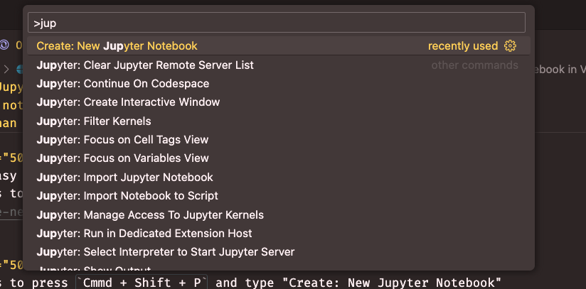

# Let’s start coding: importing packages

## Loading Packages: the `import` statement

- To use a package in your notebook, you first need to load it with `import`
- Most popular packages have a short nickname (an *alias*) that you set with the `as` keyword
  - `import pandas as pd`
  - `import matplotlib.pyplot as plt` (pyplot is the main plotting module of Matplotlib)
  - `import numpy as np`
- These aliases are a shared convention in the data science community
- Using them keeps your code shorter and easier for others to read
- If you only need one or two functions, you can grab them directly with `from`
  - `from pandas import DataFrame`
  - `from matplotlib.pyplot import plot`
- This way, you avoid loading the entire package into memory

## Loading packages: in practice

- Let’s import the “holy trinity” of data science packages in Python:

```python
# "matplotlib.pyplot" is the primary interface for plotting, aliased as 'plt'
import matplotlib.pyplot as plt

# "pandas" is used for data manipulation and analysis, aliased as 'pd'
import pandas as pd

# "numpy" is for numerical operations, especially with arrays, aliased as 'np'
import numpy as np

print("Packages (matplotlib.pyplot, pandas, numpy) loaded successfully!")
```

```
Packages (matplotlib.pyplot, pandas, numpy) loaded successfully!
```

## Opening datasets with pandas: `read_csv()`

- Pandas is excellent for working with tabular data
- The `pd.read_csv()` function is used to load data from a Comma Separated Values (CSV) file into a pandas DataFrame
- Windows users, if you encounter issues with your file path, try using double backslashes `\\` or a raw string `r'path'` to avoid escape character issues (e.g., `'C:\\path\\to\\file.csv'` or `r'C:\path\to\file.csv'`)

```python
# The pd.read_csv() function reads a CSV file.
# The result (a DataFrame) is stored in the variable 'carfeatures'.
# Ensure 'data/features.csv' is in the correct path relative to your notebook.
carfeatures = pd.read_csv('data/features.csv')

carfeatures.info() # Check the structure of the DataFrame
```

```
<class 'pandas.DataFrame'>
RangeIndex: 398 entries, 0 to 397
Data columns (total 7 columns):
 #   Column        Non-Null Count  Dtype
---  ------        --------------  -----
 0   mpg           398 non-null    float64
 1   cylinders     398 non-null    int64
 2   displacement  398 non-null    int64
 3   horsepower    397 non-null    str
 4   weight        398 non-null    int64
 5   acceleration  398 non-null    float64
 6   vehicle id    398 non-null    str
dtypes: float64(2), int64(3), str(2)
memory usage: 21.9 KB
```

## Viewing Your DataFrame in VS Code

VS Code offers several ways to inspect your DataFrame:

- Jupyter Variables Tab:
  - Look for a “Variables” icon or section in the Jupyter interface within VS Code
  - Clicking it shows active variables; double-clicking a DataFrame (like `carfeatures`) opens it in a new tab for viewing

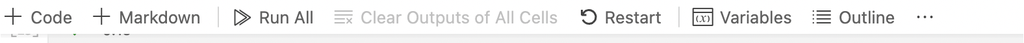

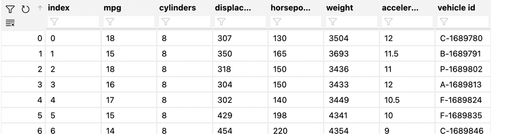

- [Data Wrangler Extension (if installed):](https://marketplace.visualstudio.com/items?itemName=ms-toolsai.datawrangler)
  - This extension provides more advanced tools for data viewing and cleaning
  - You might find a “View Data” button or a right-click option on the DataFrame variable

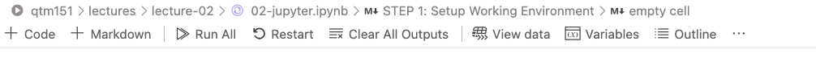

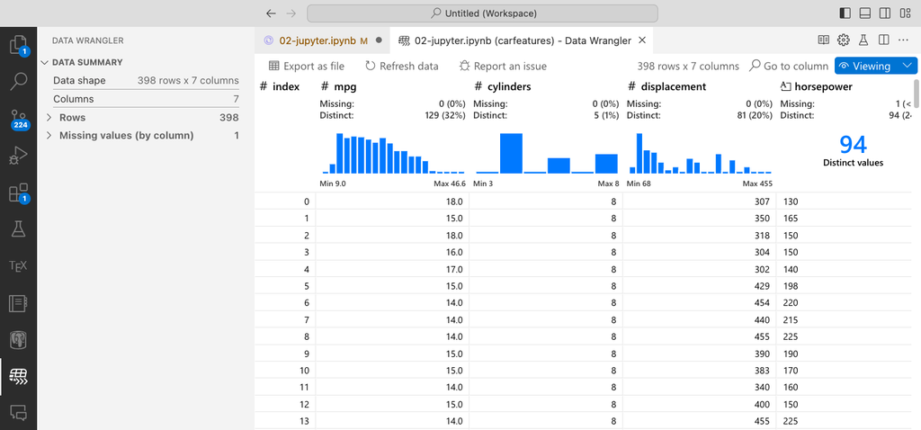

# Running basic analyses

## Displaying the `carfeatures` dataframe

- Typing the name of a DataFrame in a code cell and running it will display its contents
- For large DataFrames, Jupyter typically shows a summary (the first and last few rows)

```python
carfeatures
```

|  | mpg | cylinders | displacement | horsepower | weight | acceleration | vehicle id |
| --- | --- | --- | --- | --- | --- | --- | --- |
| 0 | 18.0 | 8 | 307 | 130 | 3504 | 12.0 | C-1689780 |
| 1 | 15.0 | 8 | 350 | 165 | 3693 | 11.5 | B-1689791 |
| 2 | 18.0 | 8 | 318 | 150 | 3436 | 11.0 | P-1689802 |
| 3 | 16.0 | 8 | 304 | 150 | 3433 | 12.0 | A-1689813 |
| 4 | 17.0 | 8 | 302 | 140 | 3449 | 10.5 | F-1689824 |
| ... | ... | ... | ... | ... | ... | ... | ... |
| 393 | 27.0 | 4 | 140 | 86 | 2790 | 15.6 | F-1694103 |
| 394 | 44.0 | 4 | 97 | 52 | 2130 | 24.6 | V-1694114 |
| 395 | 32.0 | 4 | 135 | 84 | 2295 | 11.6 | D-1694125 |
| 396 | 28.0 | 4 | 120 | 79 | 2625 | 18.6 | F-1694136 |
| 397 | 31.0 | 4 | 119 | 82 | 2720 | 19.4 | C-1694147 |

398 rows × 7 columns

## Displaying the `carfeatures` dataframe

- You can also use the `.head()` method to display the first few rows of a DataFrame

```python
# Display the first 5 rows of the DataFrame
carfeatures.head()  # Default is 5 rows
```

|  | mpg | cylinders | displacement | horsepower | weight | acceleration | vehicle id |
| --- | --- | --- | --- | --- | --- | --- | --- |
| 0 | 18.0 | 8 | 307 | 130 | 3504 | 12.0 | C-1689780 |
| 1 | 15.0 | 8 | 350 | 165 | 3693 | 11.5 | B-1689791 |
| 2 | 18.0 | 8 | 318 | 150 | 3436 | 11.0 | P-1689802 |
| 3 | 16.0 | 8 | 304 | 150 | 3433 | 12.0 | A-1689813 |
| 4 | 17.0 | 8 | 302 | 140 | 3449 | 10.5 | F-1689824 |

- To view the last few rows, use `.tail()`

```python
# Display the last 5 rows of the DataFrame
carfeatures.tail()  # Default is 5 rows
```

|  | mpg | cylinders | displacement | horsepower | weight | acceleration | vehicle id |
| --- | --- | --- | --- | --- | --- | --- | --- |
| 393 | 27.0 | 4 | 140 | 86 | 2790 | 15.6 | F-1694103 |
| 394 | 44.0 | 4 | 97 | 52 | 2130 | 24.6 | V-1694114 |
| 395 | 32.0 | 4 | 135 | 84 | 2295 | 11.6 | D-1694125 |
| 396 | 28.0 | 4 | 120 | 79 | 2625 | 18.6 | F-1694136 |
| 397 | 31.0 | 4 | 119 | 82 | 2720 | 19.4 | C-1694147 |

## Selecting and displaying a single column

- To select a single column from a DataFrame, use the column name in square brackets `[]`
- This returns a pandas Series (a one-dimensional array-like object)

```python
# Extracting the 'cylinders' column.
carfeatures['cylinders'].head()
```

```
0    8
1    8
2    8
3    8
4    8
Name: cylinders, dtype: int64
```

- You can also use the dot notation (if the column name doesn’t contain spaces or special characters)

```python
# Using dot notation
carfeatures.cylinders.head()
```

```
0    8
1    8
2    8
3    8
4    8
Name: cylinders, dtype: int64
```

- **Note:** Dot notation is less flexible than bracket notation, especially for column names with spaces or special characters

## Example: Computing a frequency table

- To count occurrences of unique values in a column, use `pd.crosstab()`
- This function creates a cross-tabulation of two (or more) variables
- The first argument is the column to be counted, and the second is a custom title for the resulting table

```python
# crosstab counts how many rows fall into categories
# "index" is the category
# "columns" is a custom title

table = pd.crosstab(index = carfeatures['cylinders'], columns = "count")
table
```

| col_0 cylinders | count |
| --- | --- |
| 3 | 4 |
| 4 | 204 |
| 5 | 3 |
| 6 | 84 |
| 8 | 103 |

## Example: Computing a frequency table

- The column name in the crosstab table is set to `col_0` by default

```python
table.columns.name
```

```
'col_0'
```

- We can rename the column too

```python
table.columns.name = 'column name'
table
```

| column name cylinders | count |
| --- | --- |
| 3 | 4 |
| 4 | 204 |
| 5 | 3 |
| 6 | 84 |
| 8 | 103 |

## Example: Generating basic summary statistics

- The `.describe()` method on a DataFrame provides key descriptive statistics for all numerical columns

```python
# .describe() computes: count, mean, standard deviation, min, 25th/50th/75th percentiles, and max
# It automatically ignores non-numeric columns
carfeatures.describe()
```

|  | mpg | cylinders | displacement | weight | acceleration |
| --- | --- | --- | --- | --- | --- |
| count | 398.000000 | 398.000000 | 398.000000 | 398.000000 | 398.000000 |
| mean | 23.514573 | 5.454774 | 193.427136 | 2970.424623 | 15.568090 |
| std | 7.815984 | 1.701004 | 104.268683 | 846.841774 | 2.757689 |
| min | 9.000000 | 3.000000 | 68.000000 | 1613.000000 | 8.000000 |
| 25% | 17.500000 | 4.000000 | 104.250000 | 2223.750000 | 13.825000 |
| 50% | 23.000000 | 4.000000 | 148.500000 | 2803.500000 | 15.500000 |
| 75% | 29.000000 | 8.000000 | 262.000000 | 3608.000000 | 17.175000 |
| max | 46.600000 | 8.000000 | 455.000000 | 5140.000000 | 24.800000 |

**Note**

The `horsepower` column might be missing from `.describe()` if it was read as non-numeric (e.g., due to placeholder characters like ‘?’). Data cleaning would be needed to convert it. You can use `carfeatures['horsepower'] = pd.to_numeric(carfeatures['horsepower'], errors='coerce')` to convert it to numeric, which will turn non-convertible values into NaN (missing values).

# Python variables & data types 📊

## Variables: Named containers for data

- Variables are used to store data values.
- Python is dynamically typed, meaning you don’t need to declare the type of a variable.
- **Common Data Types:**
  - Integers (`int`): Whole numbers (e.g., `x = 10`)
  - Floats (`float`): Numbers with decimals (e.g., `pi = 3.14`)
  - Strings (`str`): Text, enclosed in single `' '` or double `" "` quotes (e.g., `message = "Hello"`)
  - Booleans (`bool`): Logical values, either `True` or `False`
- Use `type()` to check a variable’s data type, and `print()` to show its value
- An f-string is a regular string with the letter `f` written just before the opening quote
- Anything you put inside `{}` is replaced by the value of that variable when the string is printed
- For example, if `name = "Alice"`, then `f"Hi, {name}!"` prints `Hi, Alice!`

```python
age = 30                            # Integer
price = 19.99                       # Float
student_name = "Alice"              # String
is_enrolled = True                  # Boolean

print(f"Value: {age}, Type: {type(age)}")
print(f"Value: {price}, Type: {type(price)}")
print(f"Value: {student_name}, Type: {type(student_name)}")
print(f"Value: {is_enrolled}, Type: {type(is_enrolled)}")
```

```
Value: 30, Type: <class 'int'>
Value: 19.99, Type: <class 'float'>
Value: Alice, Type: <class 'str'>
Value: True, Type: <class 'bool'>
```

## Storing variables in memory & naming conventions

- Assign values with `=`, e.g., `user_count = 150`
- **Naming rules (Python enforces these):**
  - Must start with a letter or underscore (`_`); after that, use letters, numbers, or `_`
  - Must not match a Python keyword (`if`, `for`, `class`, …)
  - Names are case-sensitive: `myVar` and `myvar` are different variables
- **Naming style (we choose these):**
  - Use `snake_case`: lowercase words joined with underscores
  - Pick descriptive names: `average_score` beats `avg`
- See your active variables in the Variables panel or Data Wrangler

```python
count_apples = 5
item_price = 2.50
user_greeting = "Welcome back!"

print(count_apples)
print(user_greeting)
```

```
5
Welcome back!
```

- Try it yourself!
- **Exercise:** Create a variable to store the title of your favourite film and print it!
- Solution

## Basic operations with variables

**Numeric Operations:**

- Addition: `+`
- Subtraction: `-`
- Multiplication: `*`
- Division: `/` (results in a float)
- Floor Division: `//` (discards decimal)
- Modulus: `%` (remainder)
- Exponentiation: `**` (e.g., `2**3` is 8)
- Use parentheses `()` to control the order of operations.

```python
total_cost = 10 * 1.08  # Price * tax
print(f"Total cost: {total_cost}")

base_number = 4
calculation = (base_number + 6) / 2
print(f"Calculation result: {calculation}")
```

```
Total cost: 10.8
Calculation result: 5.0
```

**String Concatenation:**

- Use the `+` operator to join strings.

```python
first_name = "Danilo"
last_name = "Freire"
full_name = first_name + " " + last_name
print(full_name)
```

```
Danilo Freire
```

- Try it yourself!
- **Exercise:** Define variables for your name and major, then print a concatenated string introducing yourself
- Solution

# Python lists 📝

## Lists: Ordered, mutable collections

- Lists let you store multiple items in a single variable
- Create one with square brackets `[]` and commas between items
- Items can be of different data types: numbers, strings, even other lists
- Lists are ordered: items keep their position
- Lists are mutable: you can change, add, or remove items at any time
- Access an item by its index (its position in the list)
- Python indexing starts at 0! The first item is at index `0`

## Lists: Ordered, mutable collections

```python
# List of integers
prime_numbers = [2, 3, 5, 7, 11]

# List of strings (e.g., survey responses)
fav_colours = ["blue", "green", "blue", "red", "yellow"]
print(f"Prime Numbers: {prime_numbers}, Type: {type(prime_numbers)}")
print(f"Favourite Colours: {fav_colours}")

# List with mixed data types
mixed_data_list = ["Python", 3.11, 42, True]

# Lists can be nested (a list containing other lists)
nested_list_example = [[1, 2], ["a", "b"], mixed_data_list]
nested_list_example
```

```
Prime Numbers: [2, 3, 5, 7, 11], Type: <class 'list'>
Favourite Colours: ['blue', 'green', 'blue', 'red', 'yellow']
```

```
[[1, 2], ['a', 'b'], ['Python', 3.11, 42, True]]
```

## Accessing list elements: Indexing

- Use square brackets `[]` with the index number after the list’s name
  - `my_list[0]` gets the first element
  - `my_list[1]` gets the second element
- **Negative Indexing:**
  - `my_list[-1]` gets the *last* element
  - `my_list[-2]` gets the second-to-last element
- For nested lists, use multiple index brackets: `nested_list[outer_index][inner_index]`

```python
# Using prime_numbers = [2, 3, 5, 7, 11]
print(f"First prime: {prime_numbers[0]}")      # Output: 2
print(f"Third prime: {prime_numbers[2]}")      # Output: 5
print(f"Last prime: {prime_numbers[-1]}")     # Output: 11
```

```
First prime: 2
Third prime: 5
Last prime: 11
```

## Accessing list elements: Indexing

- Using `nested_list_example = [[1, 2], ["a", "b"], ["Python", 3.11, 42, True]]`
- Let’s access `Python` from the nested list:
- The inner list `["Python", 3.11, 42, True]` is at `nested_list_example[2]`
- `Python` is the first element (index `0`) of that inner list

```python
nested_list_example = [[1, 2], ["a", "b"], ["Python", 3.11, 42, True]]
nested_list_example[2][0]
```

```
'Python'
```

- Try it yourself!
  - Create a list containing the titles of your three favourite films
  - Print the last film using both positive and negative indexing
- Solution

# Visualising data with matplotlib 📊

## Visualising list data: histograms

- `matplotlib.pyplot` (imported as `plt`) is Python’s main plotting library
- `plt.hist()` creates a histogram: useful for showing the distribution of numbers or how often each category appears in a list
- `plt.show()` draws the plot on screen
- Always add a title and axis labels:
  - `plt.title("My Plot Title")`
  - `plt.xlabel("X-axis Label")`
  - `plt.ylabel("Y-axis Label")`

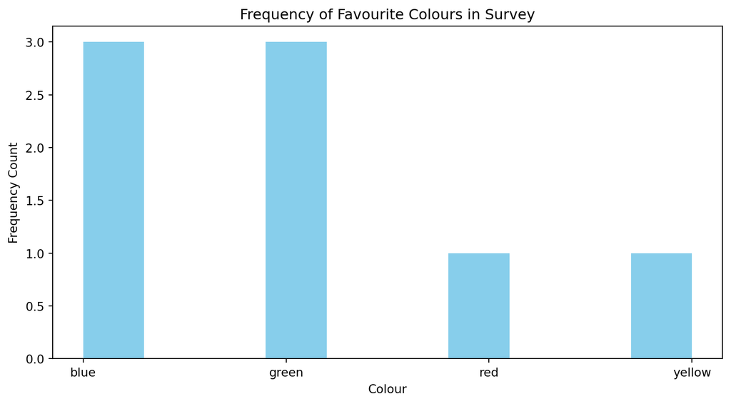

```python
# import matplotlib.pyplot as plt
# fav_colours = ["blue", "green", "blue", "red", "yellow"]
colour_survey = fav_colours + ['blue', 'green', 'green']

plt.hist(x=colour_survey, color='skyblue')
plt.title("Frequency of Favourite Colours in Survey")
plt.xlabel("Colour")
plt.ylabel("Frequency Count")
plt.show()
```

## Try it yourself!

- Create a list with repeated string values (e.g., favourite books) and generate a histogram
- Ensure you add a title, and labels for the x and y axes!

Solution

## Visualising relationships: scatter plots with lists

- `plt.scatter()` creates a scatter plot
- It needs two lists of equal length: one for the x-axis, one for the y-axis
- Scatter plots are great for spotting whether two numerical variables are related to each other (or not)

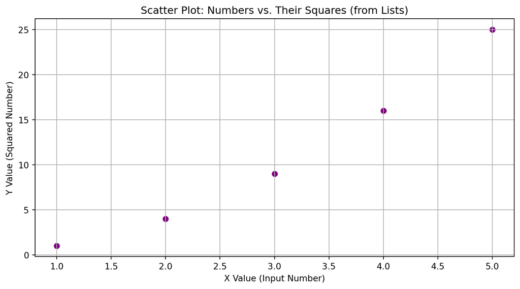

```python
x_values_list = [1, 2, 3, 4, 5]
y_values_list = [1, 4, 9, 16, 25]
plt.scatter(x=x_values_list, y=y_values_list, color='purple')
plt.xlabel("X Value (Input Number)")
plt.ylabel("Y Value (Squared Number)")
plt.title("Scatter Plot: Numbers vs. Their Squares (from Lists)")
plt.grid(True)
plt.show()
```

## Scatter plots directly from dataframe columns

- You can create scatter plots using columns from your pandas DataFrames
- The `x` and `y` parameters can be set to the names of the columns you want to plot
- Ensure the DataFrame is not empty and contains the specified columns!

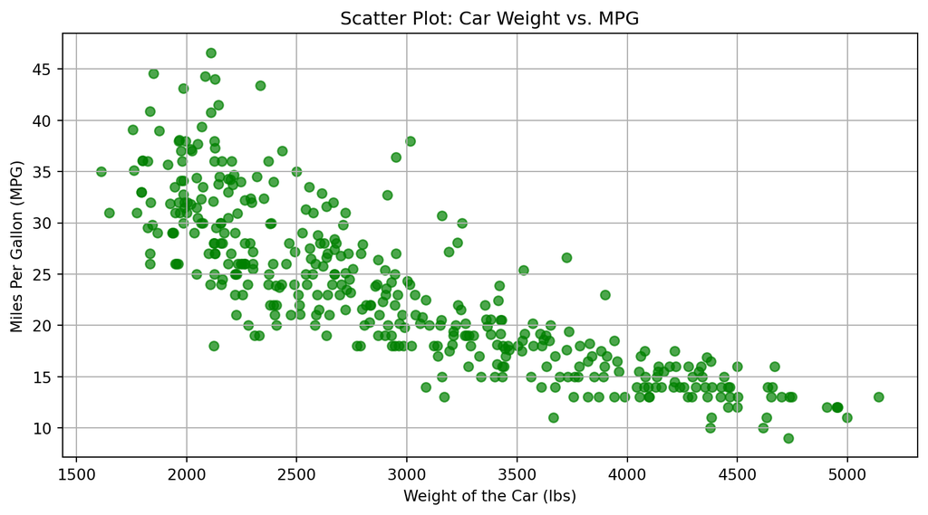

```python
# Using the 'carfeatures' DataFrame
plt.scatter(x=carfeatures['weight'], y=carfeatures['mpg'], alpha=0.7, color='green')
plt.xlabel("Weight of the Car (lbs)")
plt.ylabel("Miles Per Gallon (MPG)")
plt.title("Scatter Plot: Car Weight vs. MPG")
plt.grid(True)
plt.show()
```

**Suggestion:** Try another scatter plot using different columns, e.g., `x=carfeatures['acceleration']` vs `y=carfeatures['mpg']`.

## Try it yourself!

- Create two lists of numbers representing, for example, hours studied and exam scores.
- Generate your own scatter plot from these lists.
- Ensure you add a title, and labels for the x and y axes.

Solution

# Any questions? 🤔

# And that’s all for today! 🎉

# Appendices: Solutions to exercises

## Appendix 01

- Create a variable with your favourite film

```python
my_favourite_film = "The Godfather"
print(my_favourite_film)
```

```
The Godfather
```

Back to exercise

## Appendix 02

- Define variables for your name and major, then print an introduction

```python
user_name = "Charlie" # Variable for name
user_major = "Quantitative Sciences" # Variable for major

# Concatenating strings to form an introduction
introduction_message = "My name is " + user_name + " and I am majoring in " + user_major + "."
print(introduction_message)

# Alternative using an f-string (formatted string literal - often preferred for readability)
print(f"My name is {user_name} and I am majoring in {user_major}.")
```

```
My name is Charlie and I am majoring in Quantitative Sciences.
My name is Charlie and I am majoring in Quantitative Sciences.
```

Back to exercise

## Appendix 03

- Create a list of your three favourite films and print the last one

```python
favourite_films_list = ["Pulp Fiction", "Blade Runner 2049", "The Godfather"]

# Print the last film using positive indexing
# Length of the list is 3, so the index of the last element is 2 (3 - 1)
print(favourite_films_list[2])

# Print the last film using negative indexing (-1 always refers to the last element)
print(favourite_films_list[-1])
```

```
The Godfather
The Godfather
```

Back to exercise

## Appendix 04

- Create a list of your favourite books and generate a histogram

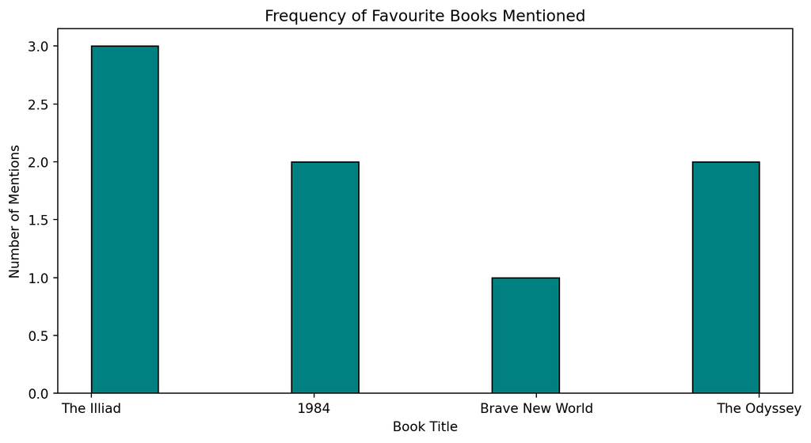

```python
# A list of favourite books, with some titles repeated
favourite_books_survey = [
    "The Illiad", "1984", "Brave New World", "The Illiad",
    "The Odyssey", "1984", "The Odyssey", "The Illiad"
]

plt.hist(x=favourite_books_survey, color='teal', edgecolor='black') # rwidth adds spacing
plt.title("Frequency of Favourite Books Mentioned")
plt.xlabel("Book Title")
plt.ylabel("Number of Mentions")
plt.show()
```

Back to exercise

## Appendix 05

- Create two lists of numbers (e.g., hours studied & exam scores) and make a scatter plot

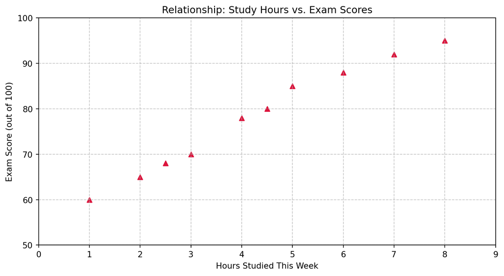

```python
# Example data: hours studied vs. exam scores
hours_studied_data = [1, 2, 2.5, 3, 4, 4.5, 5, 6, 7, 8]
exam_scores_data =   [60, 65, 68, 70, 78, 80, 85, 88, 92, 95]
plt.scatter(x=hours_studied_data, y=exam_scores_data, color='crimson', marker='^') # '^' for triangle markers
plt.xlabel("Hours Studied This Week")
plt.ylabel("Exam Score (out of 100)")
plt.title("Relationship: Study Hours vs. Exam Scores")
plt.xlim(0, 9) # Set x-axis limits
plt.ylim(50, 100) # Set y-axis limits
plt.grid(True, linestyle='--', alpha=0.7) # Add a styled grid
plt.show()
```

Back to exercise